# Pandas - Data Science with Python

Numpy and numpy arrays are our tool of choice for numeric data that resembles vectors, matrices (and higher dimensional tensors).

Where data is gathered from experiments, and in particular where we want to extract meaning from the combination of different data sources, and where data is often incomplete, the pandas library offers a number of useful tools (and has become a standard tool for data scientists).

In this section, we introduce the basics of Pandas.

In particular, we introduce the two key data types in Pandas: the `Series` and the `DataFrame` objects.

By convention, the `pandas` library is imported under the name `pd` (the same way that `numpy` is imported under the name `np`:

```python
import pandas as pd
```

## Motivational example (Series)

Imagine we are working on software for a greengrocer or supermarket, and need to track the number of apples (10), oranges(3) and bananas (22) that are available in the supermarket.

We could use a python list (or a numpy array) to track these numbers:

```python
stock = [10, 3, 22]
```

However, we would need to remember separately that the entries are in the order of apples, oranges, and bananas. This could be achieved through a second list:

```python
stocklabels = ['apple', 'orange', 'banana']
```

```python
assert len(stocklabels) == len(stock)  # check labels and
                                       # stock are consistent
for label, count in zip(stocklabels, stock):
    print(f'{label:10s} : {count:4d}')
```

```
apple      :   10
orange     :    3
banana     :   22
```

The above 2-list solution is a little awkward in two ways: firstly, we have use two lists to describe one set of data (and thus need to be carefuly to update them simulatenously, for example), and secondly, the access to the data given a label is inconvenient: We need to find the index of the label with one list, then use this as the index to the other list, for example

```python
index = stocklabels.index('banana')
bananas = stock[index]
print(f"There are {bananas} bananas [index={index}].")
```

```
There are 22 bananas [index=2].
```

We have come across similar examples in the section on dictionaries, and indeed a dictionary is a more convenient solution:

```python
stock_dic = {'apple': 10,
             'orange': 3,
             'banana': 22}
```

In a way, the keys of the dictionary contain the stock labels and the values contain the actual values:

```python
stock_dic.keys()
```

```
dict_keys(['apple', 'orange', 'banana'])
```

```python
stock_dic.values()
```

```
dict_values([10, 3, 22])
```

To retrieve (or change) the value for `apple`, we use `apple` as the key and retrieve the value through the dictionary's indexing notation:

```python
stock_dic['apple']
```

```
10
```

And we can summarise the stock as follows:

```python
for label in stock_dic:
    print(f'{label:10s} : {stock_dic[label]:4d}')
```

```
apple      :   10
orange     :    3
banana     :   22
```

This is a vast improvement over the 2-lists solution: (i) we only maintain one structure, which contains a value for every key - so we don't need to check that the lists have the same length. (ii) we can access individual elements through the label (using it as a key for the dictionary).

The Pandas Series object address the requriments above. It is similar to a dictionary, but with improvements for the given problem:

- the order of the items is maintained
- the values have to have the same type (higher execution performance)
- a (large) number of convenience functionality, for example to deal with missing data, time series, sorting, plotting, and more

## Pandas `Series`

### Stock example - `Series`

We can create a `Series` object - for example - from a dictionary:

```python
stock = pd.Series({'apple': 10,
                   'orange': 3,
                   'banana': 22})
```

The default presentation shows the entries one per row, with the label on the left, and the value on the right.

```python
type(stock)
```

```
pandas.core.series.Series
```

```python
stock
```

```
apple     10
orange     3
banana    22
dtype: int64
```

The items on the left are referred to as the `index` of the Series, and are available as the `index` attribute of the `series` object:

```python
stock.index
```

```
Index(['apple', 'orange', 'banana'], dtype='object')
```

```python
type(stock.index)
```

```
pandas.core.indexes.base.Index
```

We can also access the list of values for each item, using the `values` attribute:

```python
stock.values
```

```
array([10,  3, 22])
```

Regarding data access, the `Series` object behaves like a dictionary:

```python
stock['apple']
```

```
10
```

```python
stock['potato'] = 101    # adding more values
stock['cucumber'] = 1
```

```python
print(stock)
```

```
apple        10
orange        3
banana       22
potato      101
cucumber      1
dtype: int64
```

```python
stock
```

```
apple        10
orange        3
banana       22
potato      101
cucumber      1
dtype: int64
```

We can plot the data as a bar chart:

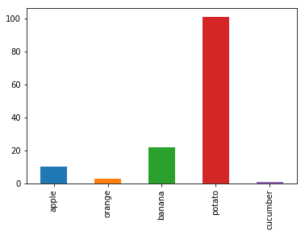

```python
%matplotlib inline
stock.plot(kind='bar')
```

We can sort the data according to the values in the Series (and then plot to visualise):

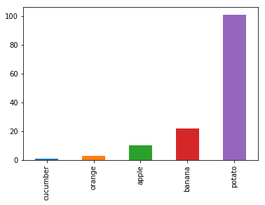

```python
stock.sort_values().plot(kind='bar')
```

Or sort the index to get alphabetical order of our fruit and vegetables:

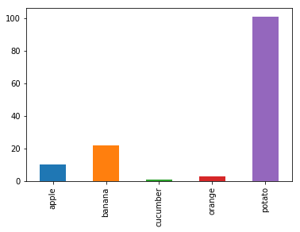

```python
stock.sort_index().plot(kind='bar')
```

The `Series` object has a number of numerical methods available, including `mean` and `sum`:

```python
stock.sum()
```

```
137
```

```python
stock.mean()
```

```
27.4
```

It also behaves like a sequence in that the `len` function returns the number of data points in the Series object:

```python
len(stock)
```

```
5
```

### memory usage

For larger data sets, it might be important to know how many bytes storing the Series costs. The bytes required to store the actual series data are available as

```python
stock.nbytes
```

```
40
```

or from the underlying numpy array directly:

```python
stock.values.nbytes
```

```
40
```

It is 40 bytes, because we have 5 elements stored as int64 (each needing 8 bytes):

```python
stock.dtype
```

```
dtype('int64')
```

The Series object needs additional memory. This can be queried using:

```python
stock.memory_usage()
```

```
240
```

### Statistics

A number of statistical descriptors of the data in the `stock` Series object is available using `describe()`:

```python
stock.describe()
```

```
count      5.000000
mean      27.400000
std       41.955929
min        1.000000
25%        3.000000
50%       10.000000
75%       22.000000
max      101.000000
dtype: float64
```

As usual, the documentation strings provide documentation (`help(stock.describe)`), and the pandas home page (`https://pandas.pydata.org`) provides links to the Pandas documentation.

## Create Series from list

In the example above, we showed how to create a Series from a dictionary where the keys of the dictionary entries served as the index for the Series object.

We can also create a Series from a list, an provide an additional index:

```python
stock = pd.Series([10, 3, 22], index=['apple', 'orange', 'banana'])
```

```python
stock
```

```
apple     10
orange     3
banana    22
dtype: int64
```

If we omit the `index` argument, the Series will assume an integer index:

```python
stock = pd.Series([10, 3, 22])
```

```python
stock
```

```
0    10
1     3
2    22
dtype: int64
```

However, an index can be added subsequently:

```python
stock.index = ['apple', 'orange', 'banana']
```

```python
stock
```

```
apple     10
orange     3
banana    22
dtype: int64
```

## Plotting data

Commonly used plots are easily accessible via the `plot()` method of the Series object. We have seen a bar plot above already. The `Series.plot()` method accepts an argument `kind` such as `kind="bar"`, but there is an equivalent method `Series.plot.bar()` avaialble.

Further examples:

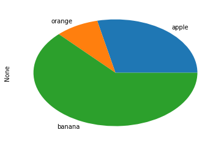

```python
stock.plot.pie()
```

To tailor the plot, we can either get the axis object and modify it subsequently:

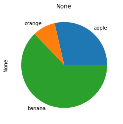

```python
ax = stock.plot.pie()
ax.set_aspect(1)
ax.set_ylabel(None);
ax.set_title(None);
```

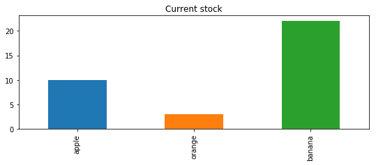

```python
import matplotlib.pyplot as plt
fig, ax = plt.subplots(1, 1, figsize=(9, 3))
stock.plot.bar(ax=ax)
ax.set_title("Current stock");
```

We can also fetch the data from the series and drive the plotting "manually" ourselves:

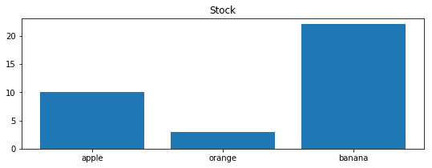

```python
import matplotlib.pyplot as plt

names = list(stock.index)
values = list(stock.values)

fig, ax = plt.subplots(1, 1, figsize=(9, 3))
ax.bar(names, values)
ax.set_title('Stock');
```

## Missing values

"Real" data sets tend to be incomplete. Dealing with missing values is an important topic in data science. The agreement in Pandas is that the special floating point value "NaN" (standing for `N`ot `a` `N`umber) represents missing data points. For example, if we have a table for the stock, but we don't know the value for `apple`, we would replace it with `NaN`.

The special `Nan` value in Python can be created using `float('nan')` or using `numpy.nan` if the `numpy` module is imported.

```python
stock['apple'] = float('nan')
```

```python
stock
```

```
apple      NaN
orange     3.0
banana    22.0
dtype: float64
```

Note that the `dtype` of the `stock` Series object has changed from `int64` to `float64` when we assigned `NaN` to `apple`: the whole series has been converted to float, because `NaN` is only defined for floating point numbers.

(There is a proposal to create a `NaN` object as part of pandas - this would overcome the above limitation.)

Assume we need to calculate how many items of stock we have in total using the `sum` function:

```python
stock.values
```

```
array([nan,  3., 22.])
```

A common situation is that we have an incomplete Series or DataFrame (which are multiple Series with the same index) and we want to process with our analysis, but treat the missing values in a special way.

```python
stock.sum()
```

```
25.0
```

The above example `sum` shows that `NaN` values are simply ignored, which can be convenient.

We can also 'tidy up' the Series object, by removing all entries that have a `NaN` value:

```python
stock.dropna()
```

```
orange     3.0
banana    22.0
dtype: float64
```

## Series data access: explicit and implicit (`loc` and `iloc`)

```python
stock = pd.Series({'apple': 10,
                   'orange': 3,
                   'banana': 22,
                   'cucumber' : 1,
                   'potato' : 110})
```

```python
stock
```

```
apple        10
orange        3
banana       22
cucumber      1
potato      110
dtype: int64
```

### Indexing

We can access single values through their index as if the stock Series object would be a dictionary:

```python
stock['banana']
```

```
22
```

There is an equivalent and recommended way of using this retrieval using the `loc` (for LOCation?) attribute:

```python
stock.loc['banana']
```

```
22
```

For convenience, pandas also (!) allows us to use integer indexing into the Series object. This is called *implicit* indexing as the series Object doesn't use integers as the index, but the name of the fruits.

For example, we can also retrieve the value for `banana` through its implicit index 2, because it is in row 3 of the Series object (which would need index 2 as we start counting from 0):

```python
stock[2]
```

```
22
```

In this example, this works fine and seems convenient, but can become very confusing if the actual index of the object consists of integers. For that reason, the explicit (and recommended way) of using the indirect indexing is through the `iloc` (ImplicitLOCation) attribute:

```python
stock.iloc[2]
```

```
22
```

### Slicing

```python
stock
```

```
apple        10
orange        3
banana       22
cucumber      1
potato      110
dtype: int64
```

We can also slice the Series:

```python
stock['orange':'potato']
```

```
orange        3
banana       22
cucumber      1
potato      110
dtype: int64
```

Or skip every second entry:

```python
stock['orange':'potato':2]
```

```
orange      3
cucumber    1
dtype: int64
```

### Data manipulation

Numerical operations on the series object can be carried for all data values at the same time inthe same way that numpy arrays are processed:

```python
stock - stock.mean()
```

```
apple      -19.2
orange     -26.2
banana      -7.2
cucumber   -28.2
potato      80.8
dtype: float64
```

```python
import numpy as np
```

```python
np.sqrt(stock)
```

```
apple        3.162278
orange       1.732051
banana       4.690416
cucumber     1.000000
potato      10.488088
dtype: float64
```

Where preferred, we can extract the numpy array and work with that:

```python
data = stock.values
```

```python
type(data)
```

```
numpy.ndarray
```

```python
data - data.mean()
```

```
array([-19.2, -26.2,  -7.2, -28.2,  80.8])
```

### Import and Export

Pandas (and its objects `Series` and `DataFrame`) support export to and import from a number of useful formats.

For example, we can write a `Series` object into a comma separated value file:

```python
stock.to_csv('stock.csv', header=False)
```

```python
#NBVAL_IGNORE_OUTPUT
!cat stock.csv
```

```
apple,10
orange,3
banana,22
cucumber,1
potato,110
```

We can also create a $\LaTeX$ representation of the table:

```python
stock.to_latex()
```

```
'\\begin{tabular}{lr}\n\\toprule\n{} &    0 \\\\\n\\midrule\napple    &   10 \\\\\norange   &    3 \\\\\nbanana   &   22 \\\\\ncucumber &    1 \\\\\npotato   &  110 \\\\\n\\bottomrule\n\\end{tabular}\n'
```

We'll come back to reading from files in the `DataFrame` section.

## Data Frame

### Stock Example - `DataFrame`

After having introduced the `Series` object above, we will focus on the second important type in pandas: the `DataFrame`.

As a first description, we could say that the `DataFrame` is similar to a (2d) spreadsheet: it contains rows and columns.

The series object we have studied above is a special case of the `DataFrame`, where the `DataFrame` has only one column.

We'll continue with our stock example:

```python
stock
```

```
apple        10
orange        3
banana       22
cucumber      1
potato      110
dtype: int64
```

In addition to tracking how many objects of each type we have stocked, we have a second Series object that provides the price per item at which the item is sold:

```python
price = pd.Series({'apple': 0.55, 'banana': 0.50, 'cucumber' : 0.99, 'potato' : 0.17, 'orange': 1.76})
price
```

```
apple       0.55
banana      0.50
cucumber    0.99
potato      0.17
orange      1.76
dtype: float64
```

The `DataFrame` object allows us to treat the two series together. In fact, a convenient way to create the `DataFrame` object is to combine a number of series as follows:

```python
shop = pd.DataFrame({'stock' : stock, 'price' : price})
shop
```

|  | stock | price |
| --- | --- | --- |
| apple | 10 | 0.55 |
| banana | 22 | 0.50 |
| cucumber | 1 | 0.99 |
| orange | 3 | 1.76 |
| potato | 110 | 0.17 |

Because both `Series` objects had the same `index` elements, our data is nicely aligned in the `DataFrame` with name `shop`, even though the data was stored in different order in the `price` and `stock`.

If one Series is missing a data point, pandas will insert a `NaN` entry into that field:

```python
price2 = price.copy()
```

```python
price2['grapefruit'] = 1.99
price2
```

```
apple         0.55
banana        0.50
cucumber      0.99
potato        0.17
orange        1.76
grapefruit    1.99
dtype: float64
```

```python
pd.DataFrame({'stock' : stock, 'price' : price2})
```

|  | stock | price |
| --- | --- | --- |
| apple | 10.0 | 0.55 |
| banana | 22.0 | 0.50 |
| cucumber | 1.0 | 0.99 |
| grapefruit | NaN | 1.99 |
| orange | 3.0 | 1.76 |
| potato | 110.0 | 0.17 |

### Accessing data in a DataFramea

```python
shop
```

|  | stock | price |
| --- | --- | --- |
| apple | 10 | 0.55 |
| banana | 22 | 0.50 |
| cucumber | 1 | 0.99 |
| orange | 3 | 1.76 |
| potato | 110 | 0.17 |

The data frame has an *index* which is the same for all columns, and shown in bold in the left most column. We can also ask for it:

```python
shop.index
```

```
Index(['apple', 'banana', 'cucumber', 'orange', 'potato'], dtype='object')
```

Each column has name (here `stock` and `price`):

```python
shop.columns
```

```
Index(['stock', 'price'], dtype='object')
```

### Extracting columns of data

Using the column names, we can extract one column into a Series object using the index operator (`[]`):

```python
shop['stock']
```

```
apple        10
banana       22
cucumber      1
orange        3
potato      110
Name: stock, dtype: int64
```

```python
shop['price']
```

```
apple       0.55
banana      0.50
cucumber    0.99
orange      1.76
potato      0.17
Name: price, dtype: float64
```

### Extracting rows of data

We have two options of extracting a row of data.

First, explicit indexing using the label of the index in that row:

```python
shop.loc['apple']             # single row is returned as series
```

```
stock    10.00
price     0.55
Name: apple, dtype: float64
```

```python
shop.loc['banana':'cucumber']  # multiple rows are returned as DataFrame
```

|  | stock | price |
| --- | --- | --- |
| banana | 22 | 0.50 |
| cucumber | 1 | 0.99 |

Second, we can use the implicit indexing (as for Series objects):

```python
shop.iloc[0]
```

```
stock    10.00
price     0.55
Name: apple, dtype: float64
```

```python
shop.iloc[1:3]
```

|  | stock | price |
| --- | --- | --- |
| banana | 22 | 0.50 |
| cucumber | 1 | 0.99 |

#### Warning

Note that there are some inconsistencies here: the explicit slicing with index labels (such as `.loc['banana':'cucumber']`) is inclusive of `cucumber`, whereas in the implicit slicing (such as `.iloc[1:3]`) the row with index `3` is *not* included.

The behaviour of `.loc` is convenient and a good design choice if labels such as strings in our `stock` example are used. The behaviour of `.iloc` is reflecting the normal Python behaviour.

It is thus understandable how we have arrived at the situation.

### Data manipulation with `shop`

The real strength of the DataFrames is that we can continue to process the data conveniently.

For example, we could work out the financial value of the items we have in stock, and add this as an extra column:

```python
shop['value'] = shop['price'] * shop['stock']
shop
```

|  | stock | price | value |
| --- | --- | --- | --- |
| apple | 10 | 0.55 | 5.50 |
| banana | 22 | 0.50 | 11.00 |
| cucumber | 1 | 0.99 | 0.99 |
| orange | 3 | 1.76 | 5.28 |
| potato | 110 | 0.17 | 18.70 |

Of course we can compute the sum, for example, to estimate the value of the total stock:

```python
shop['value'].sum()
```

```
41.47
```

If, for whatever reason, we want to swap columns with rows, we can `transpose` the data frame like a numpy array:

```python
shop.transpose()
```

|  | apple | banana | cucumber | orange | potato |
| --- | --- | --- | --- | --- | --- |
| stock | 10.00 | 22.0 | 1.00 | 3.00 | 110.00 |
| price | 0.55 | 0.5 | 0.99 | 1.76 | 0.17 |
| value | 5.50 | 11.0 | 0.99 | 5.28 | 18.70 |

## Example: European population 2017

Here is a second example to demonstrate some use cases of pandas DataFrames.

First, we get the data. It is originally from EUROSTAT (reference "demo_gind")

```python
#NBVAL_IGNORE_OUTPUT
!wget https://fangohr.github.io/data/eurostat/population2017/eu-pop-2017.csv
```

```
--2019-06-19 20:36:43--  https://fangohr.github.io/data/eurostat/population2017/eu-pop-2017.csv
Resolving fangohr.github.io... 185.199.108.153, 185.199.109.153, 185.199.111.153, ...
Connecting to fangohr.github.io|185.199.108.153|:443... connected.
HTTP request sent, awaiting response... 200 OK
Length: 1087 (1.1K) [text/csv]
Saving to: ‘eu-pop-2017.csv’

eu-pop-2017.csv     100%[===================>]   1.06K  --.-KB/s    in 0s

2019-06-19 20:36:43 (61.0 MB/s) - ‘eu-pop-2017.csv’ saved [1087/1087]
```

The data source is a comma-separated-value file (CSV), which looks like this:

```python
#NBVAL_IGNORE_OUTPUT
!head eu-pop-2017.csv
```

```
geo,pop17,pop18,births,deaths
Belgium ,11351727,11413058,119690,109666
Bulgaria,7101859,7050034,63955,109791
Czechia,10578820,10610055,114405,111443
Denmark,5748769,5781190,61397,53261
Germany,82521653,82850000,785000,933000
Estonia ,1315634,1319133,13784,15543
Ireland,4784383,4838259,62084,30324
Greece,10768193,10738868,88523,124530
Spain,46527039,46659302,390024,421269
```

Pandas has very strong support of reading files from different formats, including MS Excel, CSV, HDF5 and others. Each reading routine has a number of options to tailor the process.

Many data science projects leave the data in their original files, and use a few lines of Python code to import it.

```python
df = pd.read_csv('eu-pop-2017.csv')
```

```python
df
```

|  | geo | pop17 | pop18 | births | deaths |
| --- | --- | --- | --- | --- | --- |
| 0 | Belgium | 11351727 | 11413058 | 119690 | 109666 |
| 1 | Bulgaria | 7101859 | 7050034 | 63955 | 109791 |
| 2 | Czechia | 10578820 | 10610055 | 114405 | 111443 |
| 3 | Denmark | 5748769 | 5781190 | 61397 | 53261 |
| 4 | Germany | 82521653 | 82850000 | 785000 | 933000 |
| 5 | Estonia | 1315634 | 1319133 | 13784 | 15543 |
| 6 | Ireland | 4784383 | 4838259 | 62084 | 30324 |
| 7 | Greece | 10768193 | 10738868 | 88523 | 124530 |
| 8 | Spain | 46527039 | 46659302 | 390024 | 421269 |
| 9 | France | 66989083 | 67221943 | 767691 | 603141 |
| 10 | Croatia | 4154212 | 4105493 | 36556 | 53477 |
| 11 | Italy | 60589445 | 60483973 | 458151 | 649061 |
| 12 | Cyprus | 854802 | 864236 | 9229 | 5997 |
| 13 | Latvia | 1950116 | 1934379 | 20828 | 28757 |
| 14 | Lithuania | 2847904 | 2808901 | 28696 | 40142 |
| 15 | Luxembourg | 590667 | 602005 | 6174 | 4263 |
| 16 | Hungary | 9797561 | 9778371 | 94646 | 131877 |
| 17 | Malta | 460297 | 475701 | 4319 | 3571 |
| 18 | Netherlands | 17081507 | 17181084 | 169200 | 150027 |
| 19 | Austria | 8772865 | 8822267 | 87633 | 83270 |
| 20 | Poland | 37972964 | 37976687 | 401982 | 402852 |
| 21 | Portugal | 10309573 | 10291027 | 86154 | 109586 |
| 22 | Romania | 19644350 | 19523621 | 189474 | 260599 |
| 23 | Slovenia | 2065895 | 2066880 | 20241 | 20509 |
| 24 | Slovakia | 5435343 | 5443120 | 57969 | 53914 |
| 25 | Finland | 5503297 | 5513130 | 50321 | 53722 |
| 26 | Sweden | 9995153 | 10120242 | 115416 | 91972 |
| 27 | United Kingdom | 65808573 | 66238007 | 755043 | 607172 |

We look at the dataframe as it is, and use the 'head()' command which will only show the first 5 lines of data:

```python
df.head()
```

|  | geo | pop17 | pop18 | births | deaths |
| --- | --- | --- | --- | --- | --- |
| 0 | Belgium | 11351727 | 11413058 | 119690 | 109666 |
| 1 | Bulgaria | 7101859 | 7050034 | 63955 | 109791 |
| 2 | Czechia | 10578820 | 10610055 | 114405 | 111443 |
| 3 | Denmark | 5748769 | 5781190 | 61397 | 53261 |
| 4 | Germany | 82521653 | 82850000 | 785000 | 933000 |

The meaning of the colums, we have to get from metada information. In this case, we have the following description of the data:

- **geo**: the country in question
- **pop17**: the population count of that country as of 1 January 2017
- **pop18**: the population count of that country as of 1 January 2018
- **births**: the number of (live) births in the country during the year 2017
- **deaths**: the number of deaths in that country during the year 2017

The data is provided for all of the 28 European Union members (as of 2017).

We want to use the country as the country name as the index. We can achieve this either with

```python
df2 = df.set_index('geo')
```

```python
df2.head()
```

| geo | pop17 | pop18 | births | deaths |
| --- | --- | --- | --- | --- |
| Belgium | 11351727 | 11413058 | 119690 | 109666 |
| Bulgaria | 7101859 | 7050034 | 63955 | 109791 |
| Czechia | 10578820 | 10610055 | 114405 | 111443 |
| Denmark | 5748769 | 5781190 | 61397 | 53261 |
| Germany | 82521653 | 82850000 | 785000 | 933000 |

Note that we cannot change the index in a given DataFrame, so the `set_index()` method returns a new DataFrame. (This happens for many operations.)

An as alternative, we can also modify the import statement to already indicate which column we want to use as the index:

```python
df = pd.read_csv('eu-pop-2017.csv', index_col="geo")
```

```python
df.head()
```

| geo | pop17 | pop18 | births | deaths |
| --- | --- | --- | --- | --- |
| Belgium | 11351727 | 11413058 | 119690 | 109666 |
| Bulgaria | 7101859 | 7050034 | 63955 | 109791 |
| Czechia | 10578820 | 10610055 | 114405 | 111443 |
| Denmark | 5748769 | 5781190 | 61397 | 53261 |
| Germany | 82521653 | 82850000 | 785000 | 933000 |

We explore the data by plotting some of it:

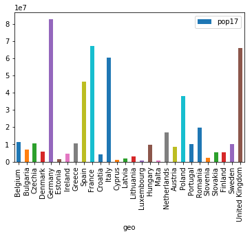

```python
df.plot(kind='bar', y='pop17')
```

The above shows the population as of 1 Jan 2017.

We'll try to improve this in two ways:

- we want to count population in millions. We can do this by dividing all the data by $10^6$.
- it would be interesting to sort the countries in order of size for this plot.

```python
df_millions = df / 1e6
```

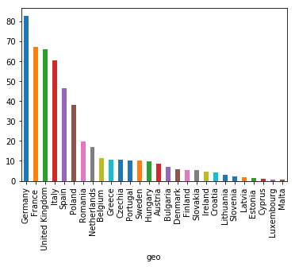

```python
df_millions['pop17'].sort_values(ascending=False).plot(kind='bar')
```

The example above selects one column from the data frame (`['pop17'`) and that returns a `Series` object. Then we sort this `Series` object using `sort_values()` according to the values (that's the number of poeple in each country), then we plot this.

Alternatively, we could also create a plot for the whole data frame, but say that the `pop17` is the column for sorting, and that we want to plot only the column with `pop17`:

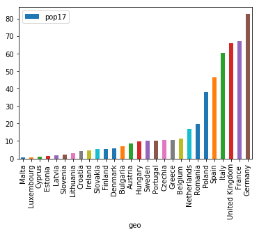

```python
df_millions.sort_values(by='pop17').plot(kind='bar', y='pop17')
```

We can also plot more than one column at the same time:

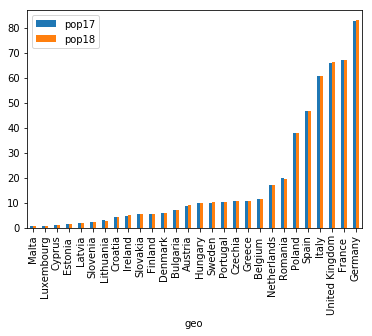

```python
ax = df_millions.sort_values(by='pop17').plot(kind='bar', y=['pop17', 'pop18'])
```

We can also fine tune the plot with the usual `matplotlib` commands:

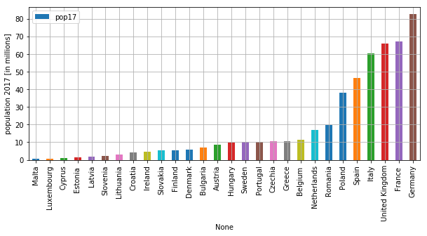

```python
ax = df_millions.sort_values(by='pop17').plot(kind='bar', y='pop17', figsize=(10, 4))
ax.set_ylabel("population 2017 [in millions]")
ax.grid()
ax.set_xlabel(None);  # get rid of default label for x-axis ('geo')
```

Based on the number of births and deaths, we can compute change in population for each country for 2017. This is sometimes called the "natural-change":

```python
df['natural-change'] = df['births'] - df['deaths']
```

```python
df['natural-change'].sort_values()
```

```
geo
Italy            -190910
Germany          -148000
Romania           -71125
Bulgaria          -45836
Hungary           -37231
Greece            -36007
Spain             -31245
Portugal          -23432
Croatia           -16921
Lithuania         -11446
Latvia             -7929
Finland            -3401
Estonia            -1759
Poland              -870
Slovenia            -268
Malta                748
Luxembourg          1911
Czechia             2962
Cyprus              3232
Slovakia            4055
Austria             4363
Denmark             8136
Belgium            10024
Netherlands        19173
Sweden             23444
Ireland            31760
United Kingdom    147871
France            164550
Name: natural-change, dtype: int64
```

From this, we can see that the population change due to births and deaths in Italy and Germany is decreasing most in absolute terms.

To relate this to the overall size of the population, one often uses rates per year and per 1000 people in the country, such as the birth rate per 1000 inhabitants [1] (and death rate accordingly):

[1] https://en.wikipedia.org/wiki/Birth_rate

```python
df['birth-rate'] = df['births'] / df['pop17'] * 1000
df['death-rate'] = df['deaths'] / df['pop17'] * 1000
df['natural-change-rate'] = df['natural-change'] / df['pop17'] * 1000
```

```python
df.head()
```

| geo | pop17 | pop18 | births | deaths | natural-change | birth-rate | death-rate | natural-change-rate |
| --- | --- | --- | --- | --- | --- | --- | --- | --- |
| Belgium | 11351727 | 11413058 | 119690 | 109666 | 10024 | 10.543770 | 9.660733 | 0.883037 |
| Bulgaria | 7101859 | 7050034 | 63955 | 109791 | -45836 | 9.005389 | 15.459473 | -6.454085 |
| Czechia | 10578820 | 10610055 | 114405 | 111443 | 2962 | 10.814533 | 10.534540 | 0.279993 |
| Denmark | 5748769 | 5781190 | 61397 | 53261 | 8136 | 10.680026 | 9.264766 | 1.415260 |
| Germany | 82521653 | 82850000 | 785000 | 933000 | -148000 | 9.512655 | 11.306123 | -1.793469 |

We can now look at the natural rate of change of population for each country, which is normalised by the population in that country.

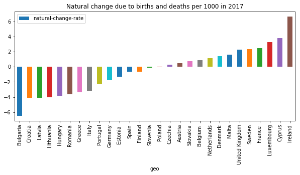

```python
ax = df.sort_values(by='natural-change-rate').plot(kind='bar', y='natural-change-rate', figsize=(10, 4))
ax.set_title("Natural change due to births and deaths per 1000 in 2017");
```

We can show the data together with the underlying birth and death rate data:

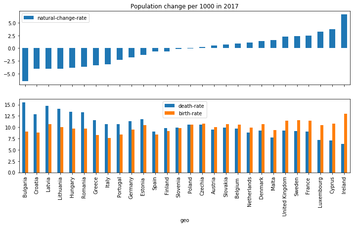

```python
tmp = df.sort_values(by='natural-change-rate')

fig, axes = plt.subplots(2, 1, figsize=(12, 6))

tmp.plot(kind='bar', y=['natural-change-rate'], sharex=True, ax=axes[0])
axes[0].set_title("Population change per 1000 in 2017")
tmp.plot(kind='bar', y=['death-rate', 'birth-rate'], sharex=True, ax=axes[1])
```

We haven't used the information we have about the population on 1 January 2018 yet.

Let's first look at the absolute changes in the population based on the (census?) data from 1 Jan 2017 and 1 Jan 2018:

```python
df['change'] = df['pop18'] - df['pop17']
```

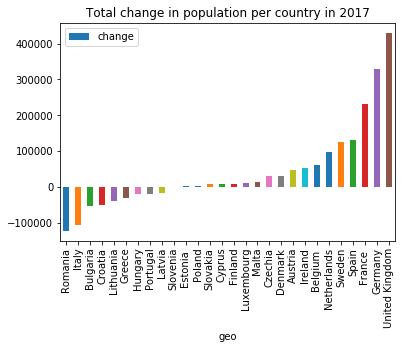

```python
ax = df.sort_values(by='change').plot(y='change', kind='bar')
ax.set_title("Total change in population per country in 2017");
```

With that information, we can estimate migration. (It is important to note that this estimated number will also absorb all inaccuracies or changes of the data gathering method, in the original data described as "statistical adjustment".)

```python
df['migration'] = df['change'] - df['natural-change']
```

```python
df.head()
```

| geo | pop17 | pop18 | births | deaths | natural-change | birth-rate | death-rate | natural-change-rate | change | migration |
| --- | --- | --- | --- | --- | --- | --- | --- | --- | --- | --- |
| Belgium | 11351727 | 11413058 | 119690 | 109666 | 10024 | 10.543770 | 9.660733 | 0.883037 | 61331 | 51307 |
| Bulgaria | 7101859 | 7050034 | 63955 | 109791 | -45836 | 9.005389 | 15.459473 | -6.454085 | -51825 | -5989 |
| Czechia | 10578820 | 10610055 | 114405 | 111443 | 2962 | 10.814533 | 10.534540 | 0.279993 | 31235 | 28273 |
| Denmark | 5748769 | 5781190 | 61397 | 53261 | 8136 | 10.680026 | 9.264766 | 1.415260 | 32421 | 24285 |
| Germany | 82521653 | 82850000 | 785000 | 933000 | -148000 | 9.512655 | 11.306123 | -1.793469 | 328347 | 476347 |

Let's plot the total change of the population per country in the top subfigure, and the contribution from natural changes and migration in the lower subfigure:

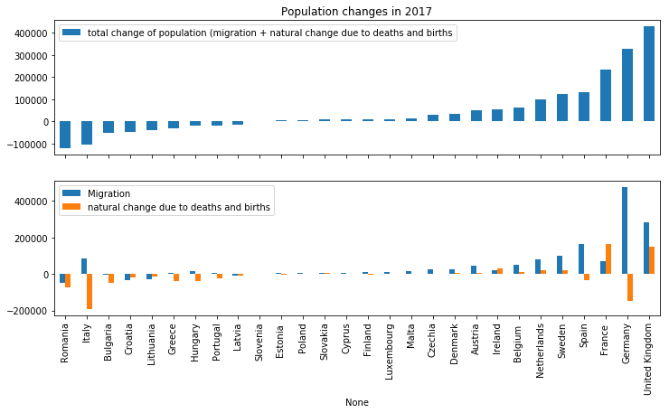

```python
tmp = df.sort_values(by='change')
fig, axes = plt.subplots(2, 1, figsize=(12, 6))

tmp.plot(kind='bar', y=['change'], sharex=True, ax=axes[0])
axes[0].set_title("Population changes in 2017")
axes[0].legend(['total change of population (migration + natural change due to deaths and births'])
tmp.plot(kind='bar', y=['migration', 'natural-change'], sharex=True, ax=axes[1])
axes[1].legend(['Migration', "natural change due to deaths and births"])
axes[1].set_xlabel(None);
```

## Further reading

There is a lot more to say about Pandas. The following resources may be useful but there are countless others available:

- Further reading on `[]`, `.loc[]` and `.iloc[]` from Ted Petrou as a [Jupyter Notebook](https://github.com/tdpetrou/Learn-Pandas/blob/master/Learn-Pandas/Selecting%20Subsets/01%20Selecting%20Subsets%20with%20%5B%20%5D%2C%20.loc%20and%20.iloc.ipynb) and [blog entry](https://medium.com/dunder-data/selecting-subsets-of-data-in-pandas-6fcd0170be9c).
- Jake VanderPlas: Python Data Science Handbook [online](https://jakevdp.github.io/PythonDataScienceHandbook/)